# Shiny (for Python) & APIs

Using Vetiver, FastAPI and Shiny

APIs

Python

Author

Martin Frigaard

Published

This is the second post demonstrating how to use Shiny apps with a database and an API (see previous post [here](https://mjfrigaard.github.io/posts/shiny-plumber/)). Both of these solutions are inspired by the exercises in the [Databases and APIs chapter](https://do4ds.com/chapters/sec1/1-3-data-access.html#lab-use-a-database-and-an-api) of [DevOps for Data Science](https://do4ds.com/).

In this post, I’ll create a simple `sklearn` model as a RESTful API with `VetiverModel` and `FastAPI`, then use a Shiny for Python app for making requests. This production-ready architecture gives users an interactive interface to the model for making predictions.

I’ll touch on coding patterns, architecture decisions, and compare my Python solution to my previous implementation using R (with `plumber`, `logger`, and `shiny`).

## Architecture

```
%%{init: {'theme': 'neutral', 'look': 'neo', 'themeVariables': { 'fontFamily': 'monospace', "fontSize":"18px"}}}%%

graph TB
    subgraph Storage["<strong>Model</strong>"]
      subgraph Board["<strong>models</strong>"]
        Model("<strong>penguin_model</strong>")
      end
    end

    style Storage fill:#fff,stroke:#E65100,color:#FF9800,stroke-width:3px
    style Board fill:#FF9800,color:#000,stroke:#FF9800,stroke-width:1px
    style Model text-align:left,fill:#FF9800,color:#000,stroke:#FF9800,stroke-width:1px

    subgraph API["<strong>Vetiver API</strong>"]
        Vetiver("<strong><code>VetiverModel</code></strong>")
        FastAPI("<strong><code>FastAPI</code> server</strong>")
        Endpoints("<code>/predict</code><br/><code>/ping</code><br/><code>/metadata</code>")
    end

    style API fill:#fff,stroke:#2E7D32,color:#4CAF50
    style Vetiver text-align:right,fill:#4CAF50,color:#000,stroke:#4CAF50,stroke-width:3px
    style FastAPI text-align:right,fill:#4CAF50,color:#000,stroke:#4CAF50,stroke-width:3px
    style Endpoints text-align:left,fill:#4CAF50,color:#000,stroke:#4CAF50,stroke-width:3px

    subgraph App["<strong>Shiny App</strong>"]
        UI("<strong>Shiny UI Inputs</strong>")
        Server("<strong>App Server</strong>")
        Logging("<strong>Logging<br>(file & console)</strong>")
    end

    style App fill:#fff,stroke:#1565C0,color:#2196F3
    style UI fill:#2196F3,color:#000,stroke:#2196F3,stroke-width:3px
    style Server fill:#2196F3,color:#000,stroke:#2196F3,stroke-width:3px
    style Logging fill:#2196F3,color:#000,stroke:#2196F3,stroke-width:3px

    subgraph User["<strong>End Users</strong>"]
        Browser("<strong>Web Browser</strong>")
    end

    style User color:#000
    style Browser fill:#fff,color:#000,stroke:#000,stroke-width:3px

    Model -->|<code>pins</code> board with <code>sklearn</code> model| Vetiver
    Vetiver -->|Model wrapper| FastAPI
    FastAPI --> |Port 8080|Endpoints

    Browser --> UI
    UI --> Server
    Server -->|HTTP POST| Endpoints
    Endpoints -->|JSON Response| Server
    Server --> Logging
    Logging --> UI
```

Python APIs & Shiny Apps

## Model

The files in the API folder are below:

```
_labs/lab4/Python/api/
                  ├── api.Rproj
                  ├── mod-api.py
                  ├── model.py
                  ├── models/
                  │   └── penguin_model/
                  ├── my-db.duckdb
                  ├── README.md
                  └── requirements.txt
```

We’ll first cover creating the model in `model.py`, then the API in `mod-api.py`.[^1]

### Dependencies

I’ll start by importing the packages. In Python (and Positron), we want to manage our Python dependencies using [`venv`](https://docs.python.org/3/tutorial/venv.html).[^2] We can accomplish this by creating the `.venv/` (virtual environment) and reading the requirements from `requirements.txt`.

```
# check  Python version
which python3
python3 --version

/usr/bin/python3 -m venv .venv
source .venv/bin/activate

pip install -r requirements.txt
```

```python
from palmerpenguins import load_penguins
from pandas import get_dummies
import numpy as np
from sklearn.linear_model import LinearRegression
from sklearn import preprocessing
import duckdb
```

Python dependencies tend to more explicit than R dependencies, specifically the “import only specific things” style (i.e., `from pandas import get_dummies`). I’m still figuring out how to use the aliases, but I’ve found that this level of precision helps me plan better (and not import something I won’t use).

**NotePython vs. R: Dependencies**

Below is a collection of terms and concepts related to dependencies in Python and R:

| Concept | Python | R | Notes |
| --- | --- | --- | --- |
| Package | Package | Package | Same word, different tooling. In Python its `pip`or`conda` and in R we use `install.packages()` or `pak`. |
| Module | module | namespace | Python modules are files; R namespaces are package-scoped environments. |
| Import | `import` or `from x import y` | `library()`,`require()`, `pkg::fun()` | Python encourages explicit imports while R encourages `pkg::fun()` for explicit usage |
| Attach | imported into namespace | attached to search path | `library()` *attaches*; `pkg::fun()` doesn’t |
| Alias | `import numpy as np` |  | R doesn’t use aliases for packages; explicit qualification is preferred. |

### Data

The data are imported from the [Python `palmerpenguins` package](https://pypi.org/project/palmerpenguins/) and used to create an embedded database connection (`con`). We then create a table from the [`pandas` DataFrame](https://pandas.pydata.org/), query and clean the data (drop missing), view the top three rows, and close the connection.

```python
penguins_data = load_penguins()
con = duckdb.connect('my-db.duckdb')
con.execute("CREATE OR REPLACE TABLE penguins AS SELECT * FROM penguins_data")
df = con.execute("SELECT * FROM penguins").fetchdf().dropna()
print(df.head(3))
con.close()
```

```
  species     island  bill_length_mm  bill_depth_mm  flipper_length_mm  body_mass_g     sex  year
0  Adelie  Torgersen            39.1           18.7              181.0       3750.0    male  2007
1  Adelie  Torgersen            39.5           17.4              186.0       3800.0  female  2007
2  Adelie  Torgersen            40.3           18.0              195.0       3250.0  female  2007
```

### Linear regression

The linear regression model uses one-hot encoding with `get_dummies()` by dropping the first category of each factor.

```python
X = get_dummies(df[['bill_length_mm', 'species', 'sex']], drop_first = True)
y = df['body_mass_g']
model = LinearRegression().fit(X, y)
```

What `get_dummies()` does is create a series of binary indicators for the categorical factors (dropped category becomes the *reference level*):

| Original Data | After `get_dummies(drop_first=True)` |
| --- | --- |
| `bill_length_mm`: 39.1 `species`: Adelie `sex`: male | `bill_length_mm`: 39.1 `species_Chinstrap`: 0 `species_Gentoo`: 0 `sex_male`: 1 |
| `bill_length_mm`: 46.5 `species`: Gentoo `sex`: female | `bill_length_mm`: 46.5 `species_Chinstrap`: 0 `species_Gentoo`: 1 `sex_male`: 0 |

*If `species_Chinstrap=0` and `species_Gentoo=0`, the penguin is `Adelie`*

**NotePython vs. R: Dummy encoding**

In Python, we have to explicitly call `get_dummies(..., drop_first = TRUE)` to perform one-hot encode the categorical variables. This drops the first level to avoid multicollinearity.

```python
X = get_dummies(df[['bill_length_mm', 'species', 'sex']], drop_first = True)
y = df['body_mass_g']
model = LinearRegression().fit(X, y)
```

In R, `lm()` will automatically convert factors to dummy variables by dropping one level per factor (also called treatment contrasts).

```r
model <- lm(
  body_mass_g ~ bill_length_mm + species + sex,
  data = df
)
```

For the [`LinearRegression` model](https://scikit-learn.org/stable/modules/generated/sklearn.linear_model.LinearRegression.html), the `.fit()` method trains the model in-place and returns `self`, enabling method chaining. We can print out the model attributes (R^2, intercept, coefficients, etc.) to confirm it’s working:

```python
# model attributes
print(f"R^2 {model.score(X,y)}")
print(f"Intercept {model.intercept_}")
print(f"Coefficients {model.coef_}")
```

**1**

The `.score()` method computes R^2 (coefficient of determination) on the training data

**2**

The `model` intercept

**3**

The `model` coefficients

**NotePython vs. R: F strings**

Python uses F-strings (any string prefixed with `f` or `F`) are formatted string literals:

```python
print(f"R^2 {model.score(X,y)}")
print(f"Intercept {model.intercept_}")
print(f"Coefficients {model.coef_}")
```

We can put *any* valid Python expression inside the braces (`` {``} ``) and these are evaluated at runtime. The results are automatically converted to strings.

In R, we can do this using base R functions:

```r
cat("R^2", summary(model)$r.squared, "\n")
cat("Intercept", coef(model)[1], "\n")
cat("Coefficients", coef(model)[-1], "\n")
```

Or the `tidyverse`-friendly output and string interpolation, `glue`:

```r
glue("R^2 {summary(model)$r.squared}")
glue("Intercept {coef(model)[1]}")
glue("Coefficients {toString(coef(model)[-1])}")
```

[output not shown]

The prototype data shows the transformation from `get_dummies()`:

```python
print(f"prototype_data {X}")
```

```
prototype_data      bill_length_mm  species_Chinstrap  species_Gentoo  sex_male
0              39.1              False           False      True
1              39.5              False           False     False
2              40.3              False           False     False
4              36.7              False           False     False
5              39.3              False           False      True
..              ...                ...             ...       ...
339            55.8               True           False      True
340            43.5               True           False     False
341            49.6               True           False      True
342            50.8               True           False      True
343            50.2               True           False     False

[333 rows x 4 columns]
```

The columns in `X` also let us know what kind of data this model will be expecting.

```python
print(f"Columns {X.columns}")
```

```
Columns Index(['bill_length_mm', 'species_Chinstrap', 'species_Gentoo', 'sex_male'], dtype='object')
```

### VetiverModel

Now we can wrap the trained `sklearn.linear_model` with metadata as a `VetiverModel` and store it as `v`:

```python
from vetiver import VetiverModel
v = VetiverModel(model, model_name='penguin_model', prototype_data=X)
```

The `prototype_data` is set to `X` (which we created above).

**NotePython vs. R: vetiver**

The `VetiverModel` Wrapper is essentially the same in Python and R: both end up with a Vetiver object that can make predictions and has some kind of prototype input structure:

```python
v = VetiverModel(model, model_name='penguin_model', prototype_data=X)
```

The `prototype_data=X` will explicitly provide the pre-dummified data.

In R, `save_prototype=TRUE`, the prototype is based on the model terms/data structure and includes the raw columns (which is we’d want for an API expecting `species` and `sex` as inputs (not pre-dummified columns). The `description` has extra metadata for documentation).

```r
v <- vetiver::vetiver_model(
  model,
  model_name = 'penguin_model',
  description = 'Linear model predicting penguin body mass from bill length, species, and sex',
  save_prototype = TRUE
)
```

### `pins` board

We’ll use `pins` to create a `model/` board (i.e., the storage directory) and save our `vetiver` versioned model.

```python
import os
from pins import board_folder
from vetiver import vetiver_pin_write

model_board = board_folder("./models", allow_pickle_read=True)
vetiver_pin_write(model_board, v)
```

**NotePython vs. R: pins**

The `pins` board is also nearly identical, with the exception of deserializing Python-specific pickled objects (`allow_pickle_read=True`):

```python
model_board = board_folder('./models', allow_pickle_read=True)
vetiver_pin_write(model_board, v)
```

In R, serialization is via RDS/qs/etc., depending on implementation and `pins` board behavior:

```r
model_board <- pins::board_folder('models/')
vetiver::vetiver_pin_write(model_board, v)
```

```
%%{init: {'theme': 'neutral', 'look': 'neo', 'themeVariables': { 'fontFamily': 'monospace', "fontSize":"18px"}}}%%

graph LR
    subgraph Board["<strong>./models/</strong>"]
        ModelDir["<strong>penguin_model/<strong>"]
        Version["<strong>20251224T142035Z-c115b/</strong>"]
        DataTxt["<code>data.txt</code>"]
        ModelFile["<code>penguin_model.joblib</code>"]
    end

    ModelDir -->|<em>timestamp with hash</em>|Version
    Version --> |<em>pin metadata</em>|DataTxt
    Version --> |<em>serialized model</em>|ModelFile

    style Board fill:#E8F5E9,stroke:#2E7D32
    style Version fill:#BBDEFB,stroke:#1565C0
    style ModelFile fill:#FF9800,stroke:#E65100,color:#fff
```

vetiver_pin_write()

The `models/` folder contains the following:

```
models/
└── penguin_model
    └── 20251224T142035Z-c115b
        ├── data.txt
        └── penguin_model.joblib

3 directories, 2 files
```

**1**

Model name

**2**

Version timestamp + hash

**3**

Pin metadata (JSON format)

**4**

Serialized sklearn model (joblib format)

## API

Now that we have a `Vetiver` model, we can build an API. At the top of the `mod-api.py` file, `warnings` and `os` are imported because we’re going to ignore the OpenSSL warning and set the `PINS_ALLOW_PICKLE_READ` environment variable (because we know the files come from a trusted source lab):[^3]

```python
# pkgs
import warnings
warnings.filterwarnings("ignore", message=".*urllib3 v2 only supports OpenSSL.*")

import os
os.environ['PINS_ALLOW_PICKLE_READ'] = '1'
```

**TipPICKLE!**

*We previously set the `allow_pickle_read` to `True` when we created the `model_board`, and now we’re specifying an environment variable. Why?*

```python
model_board = board_folder('./models', allow_pickle_read=True)
```

[Pickle](https://docs.python.org/3/library/pickle.html) is Python’s way of saving complex objects to files (it can save almost ANY Python object - functions, classes, even entire programs). But this also means `pickle` can save malicious code.

```python
os.environ['PINS_ALLOW_PICKLE_READ'] = '1'
```

After importing the libraries, we connect to the model board (that was created in `model.py`) and read the pinned model.

```python
# dependencies
import vetiver
import pins
import uvicorn
import pandas as pd

model_board = pins.board_folder("models/")

sklearn_model = model_board.pin_read("penguin_model")
```

To ensure the `sklearn_model` model has the correct input data, we validate the expected features by checking the `feature_names_in_` attribute:

```python
# features
if hasattr(sklearn_model, 'feature_names_in_'):
    feature_names = sklearn_model.feature_names_in_
    print(f"Model expects features: {list(feature_names)}")
```

This attribute are the, “*Names of features seen during [`fit`](https://scikit-learn.org/stable/glossary.html#term-fit). Defined only when X has feature names that are all strings.*”

### Prototype Data

The model prototype data–which is like a contract between the client and the API–defines the expected input schema. We define the prototype data using a `get_prototype_value()` function, which checks the column names and has some sensible validation rules (provided the model has the expected features (i.e., from `feature_names_in_` and `feature_names`)):

```python
def get_prototype_value(column_name):
    """Get appropriate default value for each column type"""
    if 'bill_length' in column_name:
        return 45.0
    elif 'species_Gentoo' in column_name:
        return 1
    elif 'sex_male' in column_name:
        return 1
    else:
        return 0

prototype_data = pd.DataFrame({
    name: [get_prototype_value(name)] for name in feature_names
})
```

**1**

Realistic penguin bill length

**2**

Default to Gentoo species

**3**

Default to male

**4**

Default for other dummy variables

**5**

Create prototype data using the raw input column names the estimator saw at fit time

If the `sklearn_model` *doesn’t contain or expose the `feature_names_in_` attribute*, we manually create `prototype_data` as a `pandas.DataFrame` with hard-coded columns:

```python
else:
    print("Model doesn't have feature_names_in_, using estimated prototype")
    prototype_data = pd.DataFrame({
        "bill_length_mm": [45.0],
        "species_Chinstrap": [0],
        "species_Gentoo": [1],
        "sex_male": [1]
    })
```

This method prevents runtime errors when the model structure doesn’t match expectations.

**NotePython vs. R: Functions, conditions, and docstrings**

#### Functions

In Python, `def` is used to define the function, `get_prototype_value`. :

```python
def get_prototype_value(column_name):
    ...
```

In R, functions are defined with `function()` (and include curly brackets if they extend past a single line):

```r
get_prototype_value <- function(column_name) {
  ...
}
```

#### Conditions

In Python, the `elif` means ‘else if’ and is evaluated only if the previous `if` condition was `FALSE`:

```python
if cond1:
    ...
elif cond2:
    ...
else:
    ...
```

In R, `else if` is explicit and typically accompanied with curly brackets (like multi-line functions).

```r
if (cond1) {
  ...
} else if (cond2) {
  ...
} else {
  ...
}
```

#### Docstrings

Python also uses [docstrings](https://www.geeksforgeeks.org/python/python-docstrings/) in their help tools (like IDEs, and documentation generators).

```python
"""Get appropriate default value for each column type"""
```

In R, `roxygen2` is used to create documentation from special comment characters:

```r
#' Get appropriate default value for each column type
```

### Wrapping and Serving

After reading `sklearn_model` from the `pins` board, we still need to convert it to `VetiverModel`:

```python
# model
v = vetiver.VetiverModel(
    model=sklearn_model,
    model_name="penguin_model",
    prototype_data=prototype_data
)
```

**1**

Wrap as `VetiverModel` and specify our `prototype_data`.

`VetiverAPI` uses the Vetiver model (`v`) to create the API (`vetiver_api`).

```python
# API
vetiver_api = vetiver.VetiverAPI(v, check_prototype=True)
```

The `check_prototype` is set to `True` because this ensures the prototype will be enforced. To view the API, we can use `vetiver_api.run()` to open the `VetiverAPI` in the browser.

```python
# View
vetiver_api.run(port = 8080)
```

We can also extract `app` from `vetiver_api`, which is the *actual* app (i.e., `<class 'fastapi.applications.FastAPI'>`). To run `app`, we’ll use `uvicorn.run()` (and include some finishing checks):

```python
# extract
app = vetiver_api.app

if __name__ == "__main__":
    print(":-] Starting Penguin Model API...")
    print(":-] API Documentation: http://127.0.0.1:8080/docs")
    print(":-] Health Check: http://127.0.0.1:8080/ping")
    print(":-] Model Info: http://127.0.0.1:8080/metadata")
    uvicorn.run(app, host="127.0.0.1", port=8080)
```

**1**

Extract `FastAPI` API object

**2**

This ensures that server-starting code only runs when the file is executed directly

**3**

Documentation and API URLs

**4**

Run the API

When `mod-api.py` is run directly, Python automatically sets a special variable called `__name__` (and it’s value is `"__main__"`). This ensures the api only starts when we explicitly run the script.

#### Console output

To run the API, we enter the following in the Terminal:

```bash
python3 mod-api.py
```

```
:-] Starting Penguin Model API...
:-] API Documentation: http://127.0.0.1:8080/docs
:-] Health Check: http://127.0.0.1:8080/ping
:-] Model Info: http://127.0.0.1:8080/metadata
INFO:     Started server process [8825]
INFO:     Waiting for application startup.
INFO:     VetiverAPI starting...
INFO:     Application startup complete.
INFO:     Uvicorn running on http://127.0.0.1:8080 (Press CTRL+C to quit)
```

Clicking on `http://127.0.0.1:8080` will open the `Vetiver` interface,

[figure not shown]

Click to enlarge

Going to `http://127.0.0.1:8080/docs` will open the `FastAPI` interface:

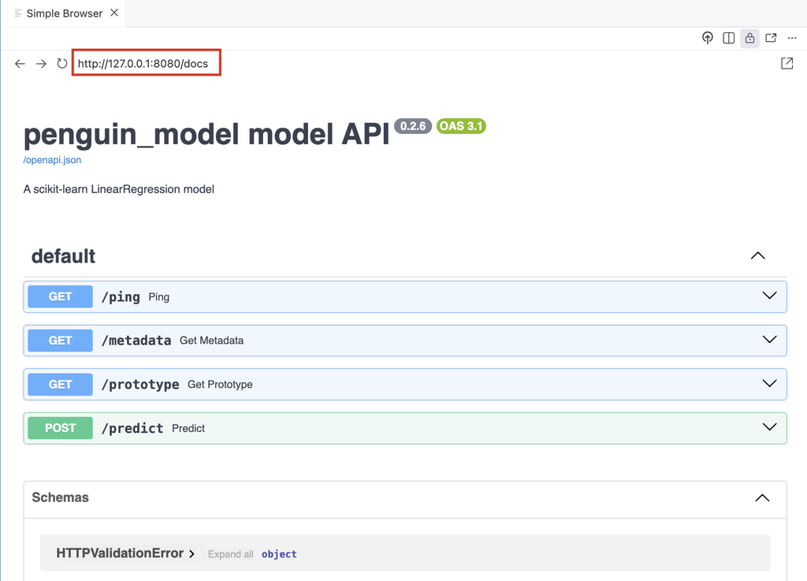

Click to enlarge

## App

The Shiny for Python app I created is in a separate [`app/` folder](https://github.com/mjfrigaard/do4ds-labs/tree/main/_labs/lab4/Python/app):

```
_labs/lab4/Python/app/
                    ├── app.py
                    ├── app.Rproj
                    ├── logs
                    │   └── shiny_app.log
                    ├── README.md
                    └── requirements.txt
```

### Dependencies

The `requirements.txt` is used to manage the `pip` dependencies (along with a virtual environment). The application modules are imported and loaded in the top of the `app.py` file:

```python
from shiny import App, render, ui, reactive
import requests
import json
import logging
import time
import os
from datetime import datetime
from pathlib import Path
```

### Logging

Logging is done using the [`logging` module](https://docs.python.org/3/library/logging.html):[^4]

```python
# config
def setup_logging():
    """Configure logging with file and console output"""
    log_dir = Path("logs")
    log_dir.mkdir(exist_ok=True)

    log_file = log_dir / "shiny_app.log"

    logging.basicConfig(
        level=logging.INFO,
        format='%(asctime)s - %(levelname)s - %(message)s',
        handlers=[
            logging.FileHandler(log_file, mode='a'),
            logging.StreamHandler()
        ]
    )

    return str(log_file)

# init
log_file_path = setup_logging()
```

**1**

Function definition for `setup_logging()`

**2**

Docstring

**3**

Location of log files (`logs/`)

**4**

Create the directory

**5**

Full path to the log file (`logs/shiny_app.log`)

**6**

Configuration of the root logging system

**7**

The log `level` of the root logger

**8**

The `format` of the root logger

**9**

The `handlers` are added to the root logger (should include a `FileHandler` and `StreamHandler`)

**10**

Sends logging output to a file

**11**

Sends logging output to console

**12**

Return log file

**13**

Run `setup_logging()` function to create `log_file_path`

The trickiest part of the `logging` configuration was making sure the logs were sent to the console *and* the `log_file`,[^5] but after reading through the tutorial (and doing some troubleshooting) I was able to get both handlers set up.[^6]

The initial contents of the `logs/shiny_app.log` file are the first and last logs in the app:

```
2026-01-02 14:23:53,666 - INFO - Shiny for Python application initialized
2026-01-02 14:23:53,733 - INFO - Shiny for Python application created successfully
```

```r
logging.info("Shiny for Python application initialized")
```

**1**

Generate first log

The second line in the log file is created at the bottom of the `app.py` file and lets us know the application launched.

```python
logging.info("Shiny for Python application created successfully")
```

### URLS

The URLS for the API are defined as `api_url` (for making predictions) and `ping_url` (for health checks).

```python
api_url = 'http://127.0.0.1:8080/predict'
ping_url = 'http://127.0.0.1:8080/ping'
```

### Sessions

The UI displays the session ID in a `div()`:

```python
  ui.div(
    ui.strong("Session: "),
    ui.output_text(id="session_display"),
    style="position: fixed; top: 10px; right: 10px; z-index: 1000; color: #333; background: #fff; padding: 5px; border-radius: 3px; box-shadow: 0 2px 4px rgba(0,0,0,0.1);"
    )
```

**1**

The `id` in the `ui.output_text()` linked to the `@render.text` in the `server`

In the `server`, we generate a session ID and log the session start:

```python
def server(input, output, session):
    session_id = f"py_{int(time.time() * 1000) % 100000}"
    logging.info(f"New session started - Session: {session_id}")
```

**1**

The `session_id` is a unique number based on `time.time()`

**2**

This new session is logged in the log file.

In the log file, we can see the `INFO` level log with the `session_id`:

```
2026-01-02 14:24:03,831 - INFO - New session started - Session: py_43831
```

The output in the application is created using a the `@render` decorator and by defining a function (matching the `id` from the UI):

```python
    @render.text
    def session_display():
        return session_id[:8]
```

**1**

Decorator for the text output

**2**

Function definition for output (matching `session_display` input `id`)

**3**

Return first 8 numbers of `session_id`

The result is a new session id in the upper right corner of the app:

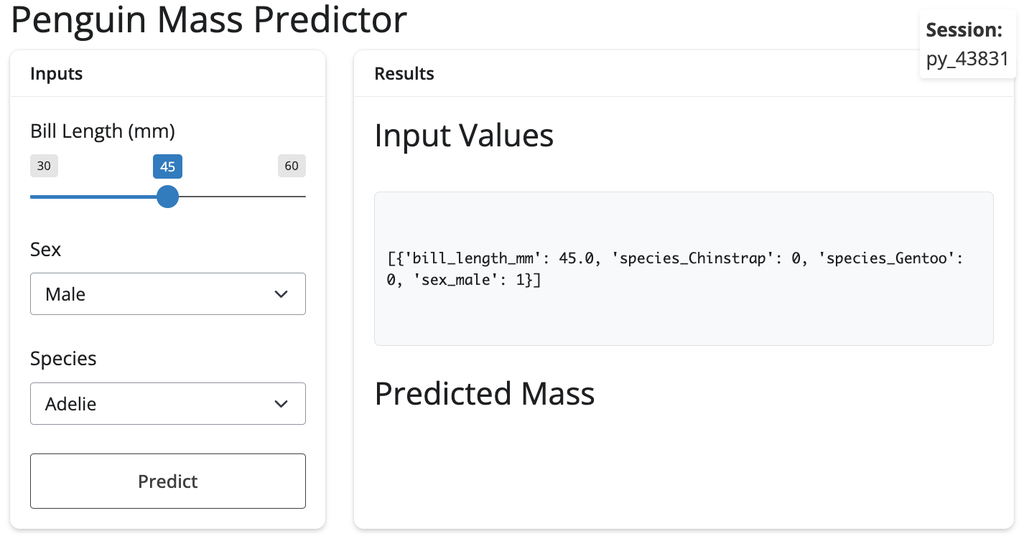

Click to enlarge

### Health check

The health check is performed using the same UI and server pattern as the session id, but it also includes the creation of a reactive (`@reactive.calc`).

First we place the `output_` component in the UI:

```python
ui.output_text(id="api_status")
```

In the server, we use a `@reactive.calc` decorator and define the `api_health_check()` function and implement **exception handling** for the health check:

**show/hide health check**

```python
    @reactive.calc
    def api_health_check():
        """Enhanced API health check with logging"""
        try:
            logging.debug(f"Checking API health - Session: {session_id}")
            start_time = time.time()
            r = requests.get(ping_url, timeout=5)
            response_time = time.time() - start_time
            if r.status_code == 200:
                logging.info(f"API health check successful - Session: {session_id} - response_time: {response_time:.3f}s")
                return f"✅ API is running (ping: {r.json()}) - {response_time:.2f}s"
              else:
                logging.warning(f"API ping failed - Session: {session_id} - status: {r.status_code}")
                return f"⚠️ API ping failed: {r.status_code}"


        except requests.exceptions.ConnectionError as e:
            logging.error(f"API connection refused - Session: {session_id} - error: {str(e)}")
            return "❌ Cannot connect to API - is it running on port 8080?"
        except requests.exceptions.Timeout:
            logging.warning(f"API health check timeout - Session: {session_id}")
            return "⚠️ API health check timeout"
        except Exception as e:
            logging.error(f"API health check failed - Session: {session_id} - error: {str(e)}")
            return f"❌ API health check failed: {str(e)}"
```

**1**

Function definition for reactive value

**2**

Docstring

**3**

The `try: ...` and `except ...` structure provide the exception handling

**4**

Request using `ping_url`

**5**

Calculated response time

**6**

Successful health check

**7**

Failed health check

**8**

Handles “cannot connect” (API down, wrong port/host, connection refused)

**9**

Handles request timeout specifically

**10**

Catch-all for anything else (JSON parsing errors, unexpected runtime issues, etc.)

The diagram below illustrates how the `@reactive.calc`, `logging`, `time` and `requests` are used to send a `ping` to the API, get a response (`r`), calculate the response time (`response_time`), return the status code (`r.status_code`), and classify the response:

```
%%{init: {'theme': 'neutral', 'look': 'neo', 'themeVariables': { 'fontFamily': 'monospace', "fontSize":"18px"}}}%%

sequenceDiagram
    participant Reactive as reactive.calc
    participant Logger as logging
    participant Timer as time
    participant Client as requests
    participant API as Vetiver API

    Reactive->>Logger: debug("Checking API health (session_id)")
    Reactive->>Timer: start_time = time.time()

    Reactive->>Client: GET ping_url (timeout=5)
    Client->>API: HTTP GET /ping
    API-->>Client: HTTP response
    Client-->>Reactive: response r

    Reactive->>Timer: response_time = time.time() - start_time

    alt status_code == 200
        Reactive->>Logger: info("Health check successful + response_time")
        Reactive-->>Reactive: return "✅ API is running"
    else status_code != 200
        Reactive->>Logger: warning("API ping failed (status_code)")
        Reactive-->>Reactive: return "⚠️ API ping failed"
    end
```

Health check with logging

**Exception handling** is created with `try` and `except`: the `request,get()` in `try` runs normally, but if an error or exception occurs, the code will jump to the first matching `except` block:

```
%%{init: {'theme': 'neutral', 'look': 'neo', 'themeVariables': { 'fontFamily': 'monospace', "fontSize":"18px"}}}%%

sequenceDiagram
    participant Reactive as reactive.calc
    participant Logger as logging
    participant Client as requests
    participant API as Vetiver API

    Reactive->>Logger: debug("Checking API health (session_id)")
    Reactive->>Client: GET ping_url (timeout=5)

    alt Normal execution
        Client->>API: HTTP GET /ping
        API-->>Client: HTTP response
        Client-->>Reactive: response r
        Reactive-->>Reactive: continue normal flow
    else ConnectionError
        Client--x Reactive: Connection refused
        Reactive->>Logger: error("Connection refused")
        Reactive-->>Reactive: return "❌ Cannot connect to API"
    else Timeout
        Client--x Reactive: Request timeout
        Reactive->>Logger: warning("Health check timeout")
        Reactive-->>Reactive: return "⚠️ API health check timeout"
    else Unexpected exception
        Reactive--x Reactive: Runtime exception
        Reactive->>Logger: error("Unexpected error")
        Reactive-->>Reactive: return "❌ API health check failed"
    end
```

Health check with exception handling

These exceptions are *typed* (e.g., `equests.exceptions.ConnectionError`, `requests.exceptions.Timeout`, etc.), which means we can match them precisely in separate `except` clauses.

**NotePython vs. R: Exception handling**

In R, exception handling can be performed using `tryCatch()`, and the errors are *conditions* (not types). We catch them with handlers (i.e., `error = function(e) ...` or `warning = ...`, `message = ...`, etc.).

Below is the same example using `logger` and `httr2`.

```r
api_health_check <- reactive({
    tryCatch({
        log_debug("Checking API health")
        start_time <- Sys.time()

        resp <- request(ping_url) |>
          req_timeout(2) |>
          req_perform()

        response_time <- as.numeric(difftime(Sys.time(), start_time, units = "secs"))
        status <- resp_status(resp)

        if (status == 200) {
          log_info("API OK - {sprintf('%.3f', response_time)}s")
          sprintf("✅ API is running - %.2fs", response_time)
        } else {
          log_warn("API ping failed - status={status}")
          sprintf("⚠️ API ping failed: %s", status)
        }
      },
      error = function(e) {
        msg <- conditionMessage(e)

        if (grepl("timed out|timeout", msg, ignore.case = TRUE)) {
          log_warn("API timeout")
          return("⚠️ API timeout")
        }

        if (grepl("Couldn't connect|Connection refused|Failed to connect", msg, ignore.case = TRUE)) {
          log_error("API connection error: {msg}")
          return("❌ Cannot connect to API")
        }

        log_error("Unexpected error: {msg}")
        sprintf("❌ Unexpected error: %s", msg)
      }
    )
  })
```

Back in the API, we see the health check was sent from the Shiny app:

```
INFO:     127.0.0.1:63543 - "GET /ping HTTP/1.1" 200 OK
```

The output is rendered in the app with the `@render.text` decorator (after defining a function the matches in input `id`).

```python
    @render.text
    def api_status():
        return api_health_check()
```

In the **System Status** section, we see the results of the `ping`:

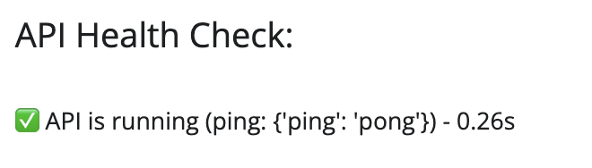

Click to enlarge

### Predictions

In the UI, the predictions get their own `div()` with some CSS styling:

```python
ui.div(
    ui.output_text("pred_out"),
    style="font-size: 24px; font-weight: bold; text-align: center; padding: 15px; color: #0066cc;"
)
```

In the server, the `@reactive.calc` for the prediction is tied to the action button input with `@reactive.event()`:

**show/hide predictions**

```python
@reactive.calc
    @reactive.event(input.predict)
    def pred():
        """Prediction with logging"""
        request_start = time.time()
        data_to_send = vals()

        logging.info(f"Starting prediction request - Session: {session_id} - request_data: {json.dumps(data_to_send)}")

        try:
            print(f"\n=== PREDICTION REQUEST ===")
            print(f"Sending data to API: {data_to_send}")

            r = requests.post(api_url, json=data_to_send, timeout=30)
            response_time = time.time() - request_start

            current_times = request_times()
            current_times.append(response_time)
            if len(current_times) > 10:
                current_times = current_times[-10:]
            request_times.set(current_times)

            print(f"HTTP Status Code: {r.status_code}")
            print(f"Raw response text: {r.text}")

            if r.status_code == 200:
                result = r.json()
                print(f"✅ Success! Parsed response: {result}")

                if '.pred' in result:
                    prediction = result['.pred'][0]
                elif 'predict' in result:
                    prediction = result['predict'][0]
                else:
                    logging.warning(f"Unexpected response format - Session: {session_id} - response: {result}")
                    return f"Unexpected response format: {result}"

                logging.info(f"Prediction successful - Session: {session_id} - response_time: {response_time:.3f}s - prediction: {prediction}")

                if response_time > 5:
                    logging.warning(f"Slow API response - Session: {session_id} - response_time: {response_time:.3f}s")

                return prediction
            else:
                error_msg = f"API Error {r.status_code}: {r.text}"
                logging.error(f"Prediction request failed - Session: {session_id} - status: {r.status_code} - response: {r.text[:200]}")
                error_count.set(error_count() + 1)
                return error_msg

        except requests.exceptions.ConnectionError as e:
            error_msg = f"Connection Error: {str(e)}"
            logging.error(f"API connection refused during prediction - Session: {session_id} - error: {str(e)}")
            connection_errors.set(connection_errors() + 1)
            error_count.set(error_count() + 1)
            print(f"❌ Connection Error: {e}")
            return error_msg
        except requests.exceptions.Timeout:
            error_msg = "Request timed out - API may be overloaded"
            logging.warning(f"API timeout during prediction - Session: {session_id}")
            timeout_errors.set(timeout_errors() + 1)
            error_count.set(error_count() + 1)
            return error_msg
        except Exception as e:
            error_msg = f"Error: {str(e)}"
            logging.error(f"Unknown prediction error - Session: {session_id} - error: {str(e)}")
            error_count.set(error_count() + 1)
            print(f"❌ Error: {e}")
            return error_msg
```

**1**

Post start time

**2**

Prediction data

**3**

Make a request

**4**

Response time

**5**

Update performance metrics

**6**

Successful request

**7**

Handle different possible response formats

**8**

Log successful request

**9**

Performance warning

**10**

Failed request

**11**

Connection error

**12**

Timeout during request

**13**

Unknown error

The `pred()` function includes the same error handling pattern as the health check, but includes defensive HTTP handling for the `POST` request:

```
%%{init: {'theme': 'neutral', 'look': 'neo', 'themeVariables': { 'fontFamily': 'monospace', "fontSize":"18px"}}}%%

graph TD
    Request["<strong>HTTP<br>Request</strong"]
    Success{"Status<br>200?"}
    Format{"Valid<br>Format?"}
    Parse("<strong>Parse<br>Prediction</strong>")
    ConnErr{"Connection<br>Error?"}
    TimeErr{"Timeout<br>Error?"}
    OtherErr["Other<br>Error"]

    Request --> Success
    Success -->|Yes| Format
    Success -->|No| LogHTTPErr("<strong>Log HTTP<br>Error</strong><br>(return<br>message)")

    Format -->|Yes| Parse
    Format -->|No| LogFormatErr["Log<br>Format<br>Warning<br>(return<br>message)"]

    Parse --> CheckPerf{Response > 5s?}
    CheckPerf -->|Yes| LogSlow["Log<br>Performance<br>Warning"]
    CheckPerf -->|No| Return["Return<br>Prediction"]
    LogSlow --> Return

    Success -->|Error| ConnErr
    ConnErr -->|Yes| LogConn("<strong>Log<br>Connection<br>Error</strong><br>(increment<br>counter)")
    ConnErr -->|No| TimeErr
    TimeErr -->|Yes| LogTimeout("<strong>Log<br>Timeout</strong><br>(increment<br>counter)")
    TimeErr -->|No| OtherErr
    OtherErr --> LogOther["Log<br>Unknown<br>Error"]

    style Request fill:#2986cc,stroke:#2E7D32,color:#fff
    style Parse fill:#4CAF50,stroke:#2E7D32,color:#fff
    style LogHTTPErr fill:#f44336,stroke:#c62828,color:#fff
    style LogConn fill:#f44336,stroke:#c62828,color:#fff
    style LogTimeout fill:#FF9800,stroke:#E65100,color:#fff
```

Python APIs & Shiny Apps

**In the console running the app**, we see the logs with the prediction request (including the data that matches the reactive values in the UI):

```
2026-01-05 14:01:01,661 - INFO - Starting prediction request - Session: py_48954
- request_data: [{"bill_length_mm": 45.0, "species_Chinstrap": 0,
  "species_Gentoo": 0, "sex_male": 1}]
=== PREDICTION REQUEST ===
Sending data to API: [{'bill_length_mm': 45.0, 'species_Chinstrap': 0,
  'species_Gentoo': 0, 'sex_male': 1}]
```

The successful request and prediction value is returned:

```
HTTP Status Code: 200
Raw response text: {"predict":[4180.796549720755]}
✅ Success! Parsed response: {'predict': [4180.796549720755]}
```

**In the console running the API**, we can see the `POST` request hit `/predict` endpoint:

```
INFO:     127.0.0.1:64436 - "POST /predict HTTP/1.1" 200 OK
```

Back in the server, the output is rendered using `@render.text` and some checks to ensure the returned prediction is in the proper format:

```python
@render.text
def pred_out():
    result = pred()
    if isinstance(result, (int, float)):
        display_value = f"{round(result, 1)} grams"
        logging.info(f"Displaying prediction to user - Session: {session_id} - display_value: {display_value}")
        return display_value
    else:
        return str(result)
```

**In the console running the app**, the successful prediction is returned and we get a preview of the predicted value to be displayed:

```
2026-01-05 14:01:02,049 - INFO - Prediction successful - Session: py_48954
  - response_time: 0.388s - prediction: 4180.796549720755
2026-01-05 14:01:02,049 - INFO - Displaying prediction to user - Session: py_48954
  - display_value: 4180.8 grams
```

We see the predicted value in the UI in the **Predicted Mass** section:

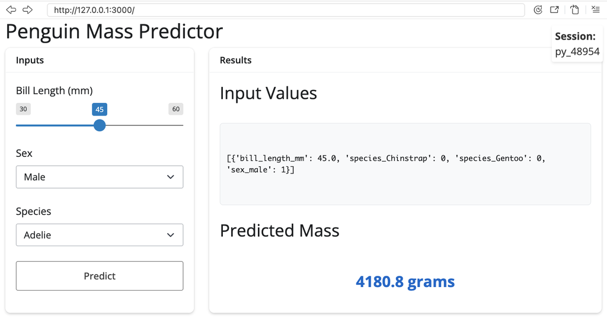

Click to enlarge

All of the logs are captured in the `logs/shiny_app.log` file (and displayed in the app):

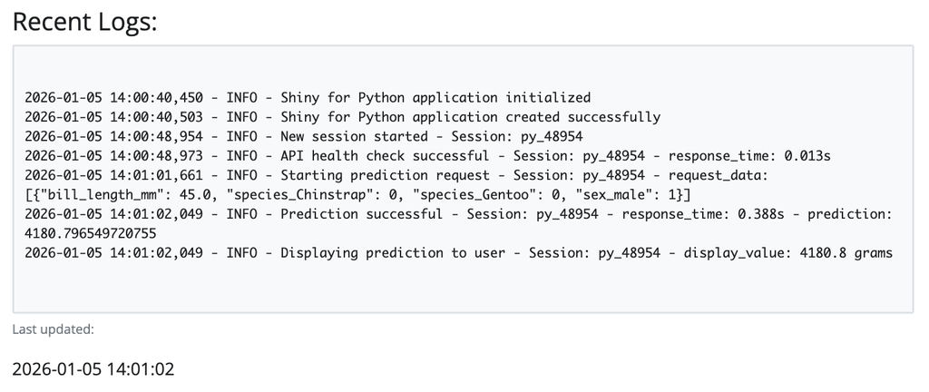

Click to enlarge

## Recap

As we’ve seen with this post (and the [previous post](https://mjfrigaard.github.io/posts/shiny-plumber/)), Python and R offer equivalent capabilities, but with different syntactic approaches for modeling, logging, and Shiny app development:

We can convert a trained `sklearn` model to Vetiver, and wrap it in a `REST` API (with validated model inputs and prototype data). We can also add health checks and documentation endpoints for monitoring and features, and model APIs also immplement request timeouts to prevent hanging.

Python’s `logging` module makes it easy to configure structured logs with consistent formats and multiple destinations (file + console). Displaying the recent logs in the UI allow us to monitor logs in real-time. The Shiny for Python app is set up to log all user interactions (via session tracking), and it can handle all HTTP error cases (with user-friendly error messages). The UI also displays the API health and POST request data before being sent to the API.

The tables below compare Python and R methods for creating models, APIs, and shiny apps.

### Model as Service

| Feature | Python (Vetiver + pins) | R (Vetiver + pins) |
| --- | --- | --- |
| **Import Packages** | `from vetiver import VetiverModel`, `from pins import board_folder` | `library(vetiver)`, `library(pins)` |
| **Create Board** | `board_folder("./models", allow_pickle_read=True)` | `board_folder("./models")` |
| **Wrap Model** | `v = VetiverModel(model, model_name="name", prototype_data=X)` | `v <- vetiver_model(model, model_name="name")` |
| **Prototype Data** | Explicitly passed: `prototype_data=X` | Auto-extracted from workflows/recipes |
| **Write Model** | `vetiver_pin_write(board, v)` | `vetiver_pin_write(board, v)` |
| **Read Model** | `v = board.pin_read("name")` | `v <- vetiver_pin_read(board, "name")` |

### Logging

| Feature | Python (`logging` module) | R (`logger` package) |
| --- | --- | --- |
| **Setup** | `logging.basicConfig()` | `log_threshold()` |
| **File Output** | `logging.FileHandler('app.log')` | `log_appender(appender_file('app.log'))` |
| **Console + File** | `handlers=[FileHandler()`, `StreamHandler()]` | `log_appender(appender_tee('app.log'))` |
| **Log Levels** | `logging.DEBUG`, `logging.INFO`, `logging.WARNING`, `logging.ERROR` | `TRACE`, `DEBUG`, `INFO`, `WARN`, `ERROR`, `FATAL` |
| **Basic Logging** | `logging.info("Message")` | `log_info("Message")` |
| **String Interpolation** | `logging.info(f"Value: {x}")` | `log_info("Value: {x}")` (glue syntax) |

### Shiny

| Feature | Python Shiny | R Shiny |
| --- | --- | --- |
| **Reactivity** | `@reactive.calc` | `reactive()` |
| **Rendering** | `@render.text` | `renderText()` |
| **Events** | `@reactive.event()` | `bindEvent()` |
| **UI** | `ui.input_slider()` | `sliderInput()` |
| **Layout** | `ui.page_fluid()` | `page_fluid()` (bslib) |

## Footnotes

[^1]: The code below has been adapted from the [modeling section](https://vetiver.posit.co/get-started/#train-a-model) of the **ML Ops with vetiver** example.
[^2]: Similar to the [`renv` package in R](https://rstudio.github.io/renv/).
[^3]: The code below is adapted from the [Deploy section](https://vetiver.posit.co/get-started/deploy.html) of the **ML Ops with vetiver** example.
[^4]: In comparison to the `logger` package in the [previous post.](https://mjfrigaard.github.io/posts/shiny-plumber/)
[^5]: Read more about ‘logging to multiple destinations’ in [Logging cookbook](https://docs.python.org/3/howto/logging-cookbook.html#logging-to-multiple-destinations)
[^6]: Logging handlers “*are responsible for dispatching the appropriate log messages (based on the log messages’ severity) to the handler’s specified destination.*”

[interactive chart not shown]